# Inferencia bayesiana for dummies (en vivo)

Esta es la versión en vivo del documento

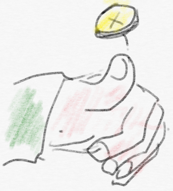

Estos datos son una muestra de lanzamientos de monedas.

`r`r X <- data.frame( toss = c(1,1,1,1,1,1,1,0,0,1,1,1,1,0,1,0,1,1,1,0,1,1,1,1,1,0,1,0,1,0,1,0,1,1,0,1,0,1,0,1,0,1,1,1,0,1,1,1,0,1) ) X

| toss |
| --- |
| 1 |
| 1 |
| 1 |
| 1 |
| 1 |
| 1 |
| 1 |
| 0 |
| 0 |
| 1 |

[output cut: 40 more lines]

Vamos a hacer un análisis bayesiano para determinar cuál es la probabilidad de que la moneda (el experimento Bernoulli en lenguaje sofisticado) valga 1.

## El modelo

Nosotros sabemos que la moneda toma valor 1 con probabilidad $\Theta$. En otras palabras
$$P(X_i = 1 | \Theta = \theta) = \theta$$
Es decir mi modelo dice que
$$X_i | \Theta \sim Ber(\Theta)$$
Aquí nuestros datos son $x=(x_1, ..., x_n)=$`toss`.

Si este es el modelo, la verosimilitud es la función
$$likelihood(\theta; X) = f_{X|\Theta}(x|\Theta = \theta) = P(X_1=x_1, ..., X_n = x_n) | \Theta = \theta) = \prod_i P(X_i=x_i|\Theta=\theta)$$

Sabemos que
$$P(X_i=1|\Theta=\theta) = \theta \quad \text{y} \quad P(X_i=0|\Theta=\theta) = 1-\theta$$
$$likelihood(\theta; X) = \theta^{\sum x_i}(1-\theta)^{n-\sum x_i}$$
Por razones numéricas que van a quedar claras más adelante, no nos gusta trabajar con la verosimilitud sino con la log-versomilitud, por lo que nos queda
$$loglikelihood(\theta;X) = (\sum x_i)log(\theta) + (n - \sum x_i)\log(1-\theta)$$

## Modelar el conocimiento previo

Para modelar conocimiento previo de probabilidades es muy útil usar la distribución Beta que depende de dos parámetros $a$ y $b$.

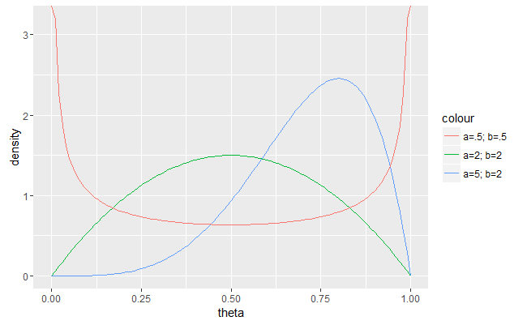

Acuérdense que lo bonito MCMC es que no me importan las constantes multiplicativas. Es decir, para efectos prácticos mi distribución a priori es
$$prior(\theta) \propto \theta^{a-1}(1-\theta)^{b-1}$$
Igual que con la verosimilitud, se suele usar la *logapriori*
$$logprior= (a-1)\log(\theta) + (b-1)\log(1-\theta) + K$$
donde la constante $K=-Beta(a,b)$ no importa,y se puede ignorar.

## Distribución posterior usando Bayes

El teorema de Bayes
$$f_{\Theta|X}(\theta|X=x) \propto f_
{X|\Theta}(x|\Theta=\theta)f_\Theta(\theta) =
likelihood*prior$$

## Diseño del MCMC

Queremos poder decir algo de la posterior. El problema en la mayoría de los casos (no en este, pero pretendamos que sí…), es que la función resultante es muy fea y requiere calcular integrales muy difíciles o que solo se pueden hacer numéricamente.

El Markov Chain Monte Carlo tiene como propósito simular observaciones de la posterior y las conclusiones que hagamos de esa muestra simulada serán conclusiones de la posterior.

Por lo tanto, la función objetivo $g$ de la cual vamos a simular es
$$g(\theta) = likelihood*prior$$

Vamos a usar el algoritmo de *Random Walk Metropolis* que es la forma más sencilla de Metropolis-Hastings. Los paso del algoritmo son:

Supongamos que vamos a simular `n_sim` observaciones y que hemos definido la función objetivo `g`. Para esta versión de Metropolis necesitamos ademas definir un parámetro $\tau$ que es tamaño de brinco. Random Walk consiste en proponer candidatos como una normal centrada en el último valor observado y el tamaño de brinco es la desviación estándar de la normal.

1. Definir una semmilla $theta_0$ que cumpla $g(theta_0)>0$.
2. Para `i=0,1,2,...`
   - Proponer un candidato $\eta$ con $g(\eta)>0$. En este caso, lo propondremos con la regla de random-walk metropolis
     $$\eta \sim N(\theta_i, \tau)$$
     .
   - Ahora hay que elegir aceptarlo o no aceptarlo con probabilidad
     $$\min\{1, g(\eta) / g(\theta_i) \}$$
     Para implementar este paso hay que simular $U\sim unif(0,1)$ y poner $\theta_{i+1} = \eta$ si $U\leq g(\eta)/g(\theta_i)$ y de lo contrario regresar al punto anterior para proponer un nuevo candidato.

Una nota más… queremos trabajar con logaritmos, entonces la condición para aceptar la vamos a reemplazar por
$$\log(U) \leq \log(g(\eta)) - \log(g(\theta_i))$$
donde
$$\log(g(\theta)) = loglikelihood + logprior$$
## Implementación de la simulación

`cpp`cpp #include <Rcpp.h> using namespace Rcpp;

// [[Rcpp::export]] double loglikelihood(double theta, NumericVector toss) { double sumx = sum(toss); int n = toss.size(); return sumx*log(theta) + (n-sumx)*log(1-theta); }

// [[Rcpp::export]] double logprior(double theta, double prior_a, double prior_b) { return (prior_a - 1)*log(theta) + (prior_b - 1)*log(1-theta); }

// [[Rcpp::export]] double logposterior( double theta, NumericVector toss, double prior_a, double prior_b) { // return loglikelihood(theta, toss) + logprior(theta, prior_a, prior_b); }

// [[Rcpp::export]] NumericVector run_mcmc( int n_sim, double theta_0, NumericVector toss, double jump, double prior_a, double prior_b ) { NumericVector sim(n_sim + 1); // aqui voy a guardar las simulaciones sim[0] = theta_0; double U, eta; bool accepted; for (int i=0; i < n_sim; i++) { // do while hasta que acepte el candidato do { eta = (rnorm(1, sim[i], jump))[0]; // genera el candidato U = (runif(1))[0]; if (eta < 0 || eta > 1) { accepted = false; } else { accepted = (log(U) <= logposterior(eta, toss, prior_a, prior_b) - logposterior(sim[i], toss, prior_a, prior_b)); } } while (!accepted); sim[i + 1] = eta; } return sim; }

Probando al verosimilitud.

`r`r loglikelihood(theta = .7, toss = X$toss)

```
[1] -30.54322
```

`r`r loglikelihood(theta = .5, toss = X$toss)

```
[1] -34.65736
```

`r`r loglikelihood(theta = .3, toss = X$toss)

```
[1] -47.48917
```

Probando la a priori.

`r`r logprior(theta = .5, prior_a = .1, prior_b = .1)

```
[1] 1.247665
```

`r`r logprior(theta = .5, prior_a = 2, prior_b = 2)

```
[1] -1.386294
```

Probando la posterior

`r`r logposterior(theta = .5, toss = X$toss, prior_a = .1, prior_b = .1)

```
[1] -33.40969
```

`r`r logposterior(theta = .5, toss = X$toss, prior_a = 2, prior_b = 2)

```
[1] -36.04365
```

Probemos la cadena de simulaciones.

`r`r post_sim <- run_mcmc( theta_0 = .1, n_sim = 100, jump = .05, toss = X$toss, prior_a = .3, prior_b = .3 ) head(post_sim)

```
[1] 0.1000000 0.1362479 0.1470910 0.1674940 0.1705039 0.2375263
```

## Diagnóstico

Vamos a ver que hizo la simulación.

### Exploración del espacio parametral

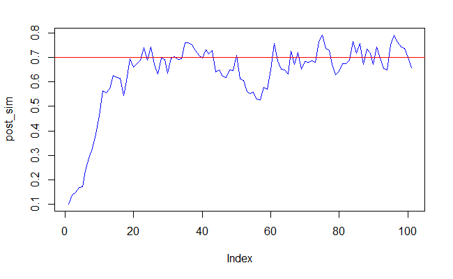

En este ejemplo de juguete (rara vez en la vida real) si podemos graficar la posterior.

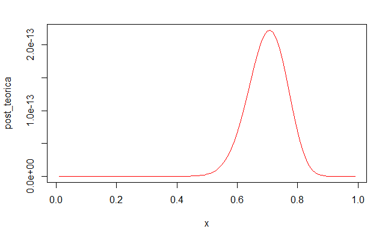

`r`r hist(post_sim, breaks= 20)

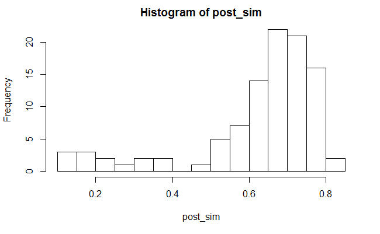

### Burnin

Observemos en el histograma anterior, que hay unos valores que dependen mucho del parámetro inicial. Por eso, siempre en MCMC, “quemamos” las primeras obervaciones.

En los métodos populares existe la opción del *burnin* que les dice cuánto o que porcentaje van a eliminar de las primeras observaciones. Si repetimos el histograma anterior quemando el primer 15% obtenemos lo siguiente.

`r`r post_sim_burnt <- post_sim[16:100] hist(post_sim_burnt)

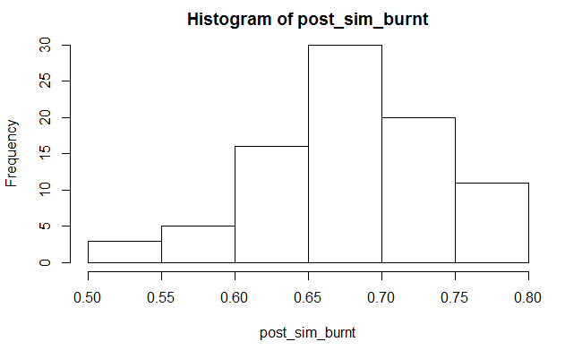

### Autocorrelación

La autocorrelación es una medida estadística que dice en una serie de tiempo cuanto depende una observación de las anteriores. En algunas ocasiones (raras en mi experiencia) necesitamos tratar a la simulación como observaciones independientes. Para eso se **adelgaza** brincandose ciertas observaciones.

`r`r acf(post_sim_burnt)

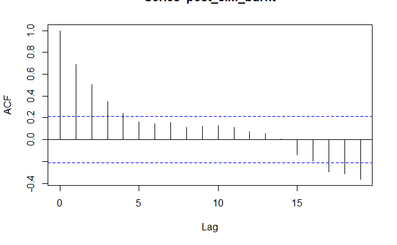

Si yo necesitara una muestra de observaciones no correlacionadas de la distribución posterior podría tomar solo una de cada cinco observaciones basado en al gráfica de autocorrelación. En general, demasiada autocorrelación significa que aceptamos demasiado y puede ser peligroso.

## Bueno… ¿y cuál es la probabilidad de la moneda?

Vamos a construir intervalos de probabilidad. En este ejemplo, intervalos de probabilidad del 90%.

`r`r quantile(post_sim_burnt, probs = c(.05, .95))

```
       5%       95%
0.5587249 0.7629198
```

Esto les dice que el valor de la moneda está con probabilidad 90% en este intervalo.